# The normal distribution

In this lab, you’ll investigate the probability distribution that is most central to statistics: the normal distribution. If you are confident that your data are nearly normal, that opens the door to many powerful statistical methods. Here we’ll use Rguroo to assess the normality of our data and also generate random numbers from a normal distribution.

## Getting Started

### The data

This week you’ll be working with fast food data. This data set contains data on 515 menu items from some of the most popular fast food restaurants worldwide.

As usual, find the dataset in the Repository, view the codebook, and then import the dataset to your Data section. Then, view the `Dataset Summary` and the first 100 rows and 15 columns of the dataset.

You’ll see that for every observation there are 17 measurements, many of which are nutritional facts.

You’ll be focusing on just three columns to get started: restaurant, calories, calories from fat.

Let’s first focus on just products from McDonalds and Dairy Queen. To do this, we’ll need to use the Rguroo Subset dialog. In the Data sections, select Functions, then Subset. In the dialog that pops up, select your Dataset, then find the `Logical Expression` button and click it.

We’ll need to include two logical expressions, one to select the McDonalds restaurants and one to select Dairy Queen. In the Logical Expression section, click the `+` button to add a new logical expression, then create the expression to select McDonalds restaurants using the dropdown menus.

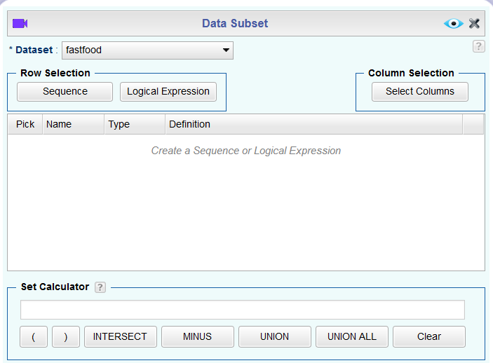

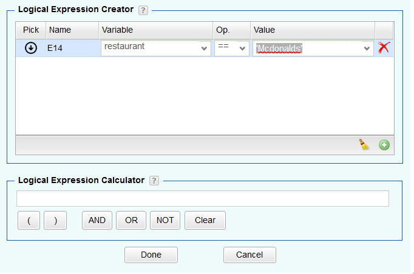

Once everything is set up correctly, click Done and view the output. Save the new dataset as `mcdonalds`. Repeat the Subset steps for Dairy Queen and save that dataset as `dairyqueen`.

1. Make plots to visualize the distributions of the amount of calories from fat (variable `cal_fat`) of the options from these two restaurants. How do their centers, shapes, and spreads compare?

## The normal distribution

In your description of the distributions, did you use words like *bell-shaped* or *normal*? It’s tempting to say so when faced with a unimodal symmetric distribution.

To see how accurate that description is, you can plot a normal distribution curve on top of a histogram to see how closely the data follow a normal distribution. This normal curve should have the same mean and standard deviation as the data.

In Rguroo, this can be done by opening the menu for the histogram and, in the Smoothing section, checking the `Normal` box. The screenshot below shows this for the `dairyqueen` dataset.

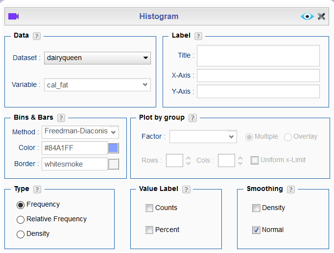

Strictly speaking, the normal distribution curve should display a normal probability density function that has area under the curve of 1. However, Rguroo scales this curve to an appropriate height on the y-axis.

If this is annoying to you, you can reopen the menu and change the `Type` option from `Frequency` to `Density`. The difference between a frequency histogram and a density histogram is that while in a frequency histogram the *heights* of the bars add up to the total number of observations, in a density histogram the *areas* of the bars add up to 1. The area of each bar can be calculated as simply the height *times* the width of the bar. Frequency and density histograms both display the same exact shape; they only differ in their y-axis. You should not see any obvious difference just looking at your new histogram.

The default option for the normal curve is a solid red line. To change attributes of the line, open the `Details` dialog, select the `Bins, Bars, Smoothing` menu and `Normal` tab, then change the attributes of the line. In the screenshot below we have changed the line to be dotted and black.

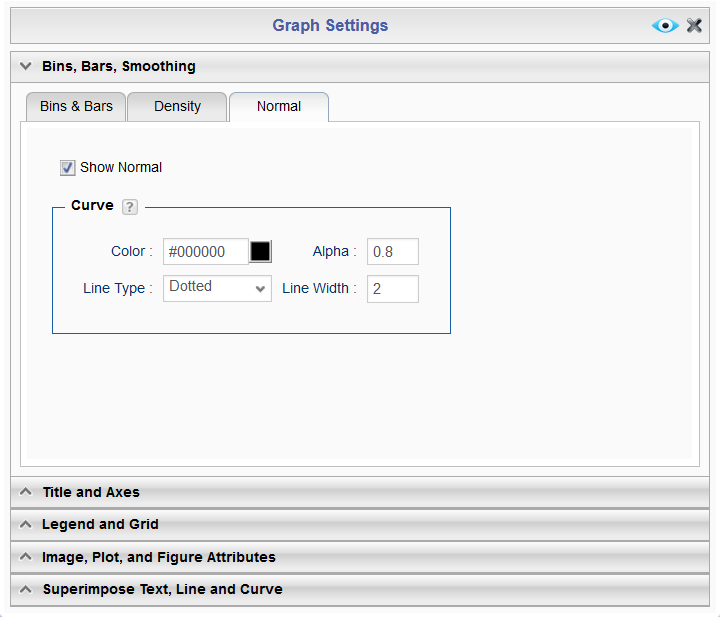

2. Based on the this plot, does it appear that the data follow a nearly normal distribution?

## Evaluating the normal distribution

Eyeballing the shape of the histogram is one way to determine if the data appear to be nearly normally distributed, but it can be frustrating to decide just how close the histogram is to the curve, especially if the shape noticeably changes when you choose a different set of bins! An alternative approach involves constructing a normal probability plot, also called a normal Q-Q plot for “quantile-quantile”.

This plot is not part of the Plots section in Rguroo; instead, we will have to go to the Analytics section. In Analytics, click the Analysis button and find Mean Inference -> One Population. As usual, select the Dataset and Variable to be plotted. Then, check the `Normal Probability Plot` box and View the output.

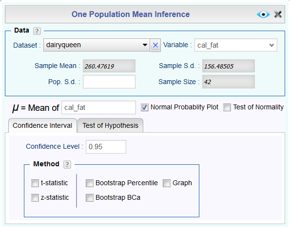

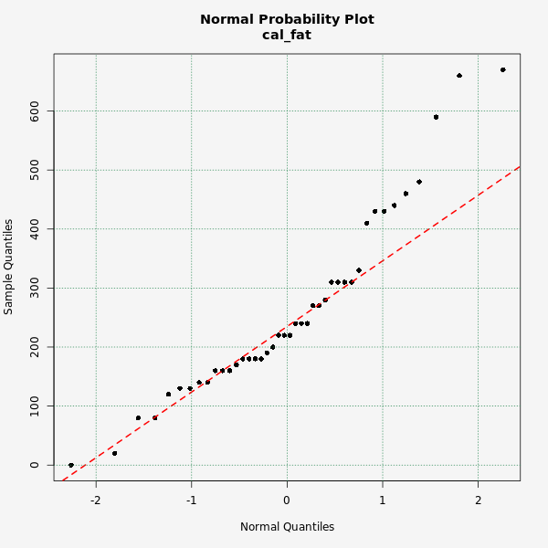

The x-axis values correspond to the quantiles of a theoretically normal curve with mean 0 and standard deviation 1 (i.e., the standard normal distribution). The y-axis values correspond to the quantiles of the original unstandardized sample data. However, even if we were to standardize the sample data values, the Q-Q plot would look identical. A data set that is nearly normal will result in a probability plot where the points closely follow a diagonal line. Any deviations from normality leads to deviations of these points from that line.

The plot for Dairy Queen’s calories from fat shows points that tend to follow the line but with some errant points towards the upper tail. You’re left with the same problem that we encountered with the histogram above: how close is close enough and how far is too far?

A useful way to address this question is to rephrase it as: what do probability plots look like for data that I *know* came from a normal distribution? We can answer this by simulating data from a normal distribution.

As you might expect, you’ll need to go to the Probability-Simulation section for this. In that section, click Probability and then Random Generator. The default distribution is Normal, but with mean 0 and standard deviation 1. If you go back to the tab with the normal probability plot, you should see a summary with the sample size, mean and standard deviation of `cal_fat` for the `dairyqueen` dataset. Fill in those values in the appropriate places in the `Random Number Generator` dialog, then View the output.

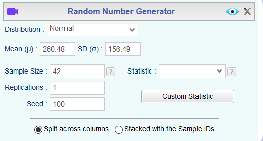

Save the dataset as `sim_norm`. Note that in Rguroo there are two `Save As` text boxes. The left box allows you to save the dialog that created the dataset to your Probability-Simulation section (for example, to use as a template any time you need to generate random numbers from a normal distribution). The right dialog box allows you to save the result as a dataset. We want to save the dataset, though it’s not a bad idea to also save the dialog as well.

3. Make a normal probability plot of `sim_norm`. Note that the default variable name (which cannot be changed) is `Sample`. Do all of the points fall on the line? How does this plot compare to the probability plot for the real data?

Even better than comparing the original plot to a single plot generated from a normal distribution is to compare it to many more plots using the following function. It shows the Q-Q plot corresponding to the original data in the top left corner, and the Q-Q plots of 8 different simulated normal data. It may be helpful to click the zoom button in the plot window.

```r
qqnormsim(sample = cal_fat, data = dairy_queen)
```

[output not shown]

## Normal probabilities

Okay, so now you have a slew of tools to judge whether or not a variable is normally distributed. Why should you care?

It turns out that statisticians know a lot about the normal distribution. Once you decide that a random variable is approximately normal, you can answer all sorts of questions about that variable related to probability. Take, for example, the question of, “What is the probability that a randomly chosen Dairy Queen product has more than 600 calories from fat?”

If we assume that the calories from fat from Dairy Queen’s menu are normally distributed (a very close approximation is also okay), we can find this probability by calculating a Z score and consulting a Z table (also called a normal probability table). This is tedious to do by hand, so most statistical software (including Rguroo) has automated the process.

In the Probability-Simulation section, click Probability, then find Probability Calculator -> Continuous. Again, the default distribution is normal, so we don’t have to change the Distribution, but we should change the Mean and Standard Deviation to their values for the `dairyqueen` dataset. Finally, we should tell Rguroo that we want the probability that a Dairy Queen item has `Above 600` calories from fat:

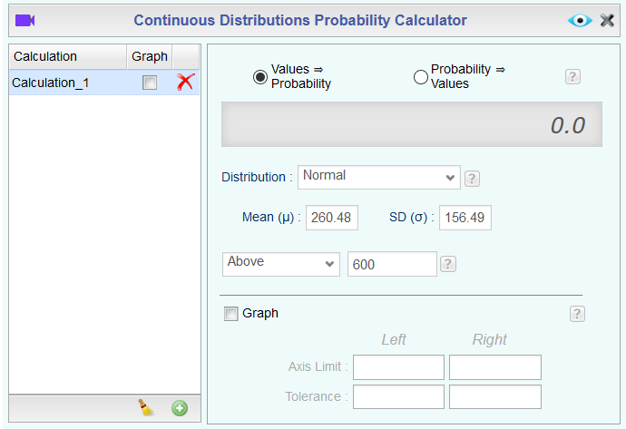

You can also see how the probability corresponds to the area under the normal density curve by checking the `Graph` box and Viewing the output.

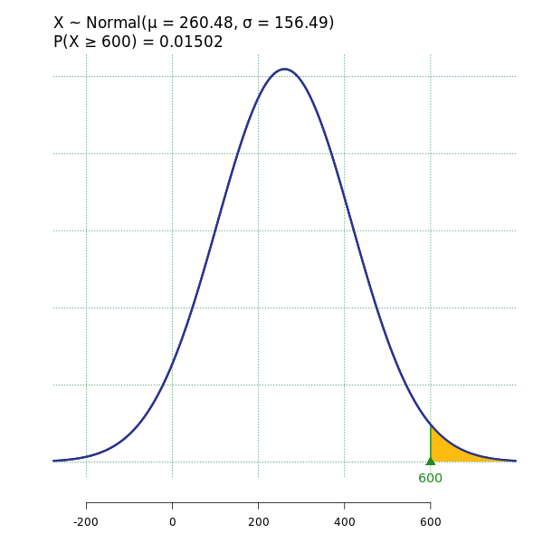

Assuming a normal distribution has allowed us to calculate a theoretical probability. If we want to calculate the probability empirically, we simply need to determine how many observations fall above 600 then divide this number by the total sample size.

There are a variety of ways to do this in Rguroo. Probably the easiest way to do this is with the `Transform` dialog. Note that here we add logical variables. Rguroo interprets TRUE as 1 and FALSE as 0, so this is essentially counting the number of Dairy Queen items with more than 600 calories, and dividing the result by the number of Dairy Queen items with at least 0 calories (i.e., all of them). One strange thing about the result is that the probability will be shown in every row of the output.

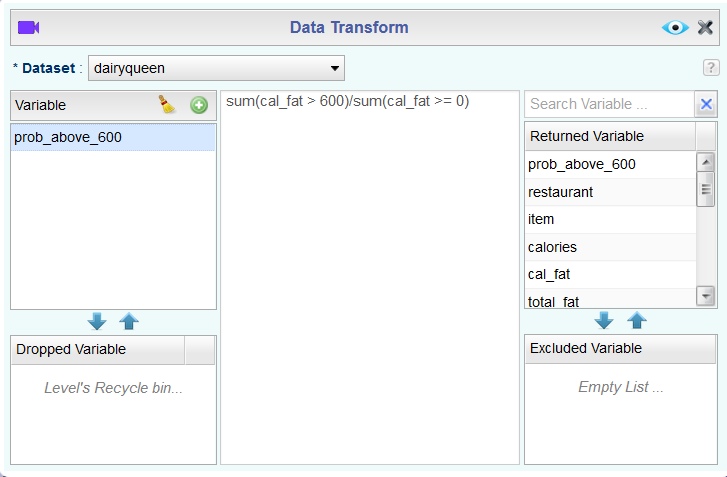

6. Write out two probability questions that you would like to answer about any of the restaurants in this dataset. Calculate those probabilities using both the theoretical normal distribution as well as the empirical distribution (four probabilities in all). Which one had a closer agreement between the two methods?

## More Practice

7. Now let’s consider some of the other variables in the dataset. Out of all the different restaurants, which ones’ distribution is the closest to normal for sodium?
8. Note that some of the normal probability plots for sodium distributions seem to have a stepwise pattern. why do you think this might be the case?
9. As you can see, normal probability plots can be used both to assess normality and visualize skewness. Make a normal probability plot for the total carbohydrates from a restaurant of your choice. Based on this normal probability plot, is this variable left skewed, symmetric, or right skewed?  
   Use a histogram to confirm your findings.

This work is licensed under a [Creative Commons Attribution-ShareAlike 4.0 International License](http://creativecommons.org/licenses/by-sa/4.0/).